# Eksploracyjna Analiza Danych

Kacper Urbański

2024-12-06

## Wstęp

Wykorzystane przeze mnie dane przedstawiają szczegółowe informacje o zawodnikach grających w tegorocznym sezonie włoskiej ligi Serie A. Zawierają one informacje dotyczące statystyk każdego piłkarza, który wystąpił w każdym rozegranym meczu do dnia 25 listopada.

Zbiór danych zawiera 33 zmienne, które obejmują m.in.:

- Podstawowe informacje o zawodnikach (np. wiek, narodowość, drużyna),
- Szczegółowe statystyki meczowe ( liczba goli, asyst, minut spędzonych na boisku),
- Wskaźniki, takie jak oczekiwane bramki, oczekiwane asysty czy procent udanych podań.

### Pakiety, których używam

```r
library(tidyverse)
library(ggplot2)
library(forcats)
library(dplyr)
library(tidyr)
library(stringr)
library(readr)
library(mice)
```

### Załadowanie danych

```r
data <- read_csv("database.csv")
```

## Poznanie danych

### 1. Struktura pliku

Teraz postaram się poznać strukturę danych.

```r
str(data)
```

```
## spc_tbl_ [3,978 × 33] (S3: spec_tbl_df/tbl_df/tbl/data.frame)
##  $ Player                : chr [1:3978] "Vitinha" "Junior Messias" "Morten Frendrup" "Milan Badelj" ...
##  $ Team                  : chr [1:3978] "Genoa" "Genoa" "Genoa" "Genoa" ...
##  $ #                     : num [1:3978] 9 10 32 47 21 17 2 3 59 20 ...
##  $ Nation                : chr [1:3978] "POR" "BRA" "DEN" "CRO" ...
##  $ Position              : chr [1:3978] "FW" "FW,RW" "CM" "CM" ...
##  $ Age                   : chr [1:3978] "24-155" "33-096" "23-132" "35-174" ...
##  $ Minutes               : num [1:3978] 90 90 90 85 5 70 20 90 70 20 ...
##  $ Goals                 : num [1:3978] 0 1 0 0 0 0 0 0 0 0 ...
##  $ Assists               : num [1:3978] 0 0 0 0 0 0 0 0 0 0 ...
##  $ Penalty Shoot on Goal : num [1:3978] 0 0 0 0 0 0 0 0 0 0 ...
##  $ Penalty Shoot         : num [1:3978] 0 1 0 0 0 0 0 0 0 0 ...
##  $ Total Shoot           : num [1:3978] 3 2 1 1 0 1 1 0 0 1 ...
##  $ Shoot on Target       : num [1:3978] 1 2 1 0 0 0 0 0 0 0 ...
##  $ Yellow Cards          : num [1:3978] 0 0 0 0 0 0 0 0 0 0 ...
##  $ Red Cards             : num [1:3978] 0 0 0 0 0 0 0 0 0 0 ...
##  $ Touches               : num [1:3978] 28 23 34 38 5 29 6 40 10 10 ...
##  $ Dribbles              : num [1:3978] 0 0 1 1 0 1 0 3 0 0 ...
##  $ Tackles               : num [1:3978] 0 1 3 0 0 1 0 1 0 1 ...
##  $ Blocks                : num [1:3978] 2 0 2 2 0 0 1 0 0 1 ...
##  $ Expected Goals (xG)   : num [1:3978] 0.2 1 0 0.1 0 0 0.1 0 0 0 ...
##  $ Non-Penalty xG (npxG) : num [1:3978] 0.2 0 0 0.1 0 0 0.1 0 0 0 ...
##  $ Expected Assists (xAG): num [1:3978] 0 0.1 0 0.1 0 0 0 0 0 0.1 ...
##  $ Shot-Creating Actions : num [1:3978] 5 4 1 2 0 1 0 2 0 1 ...
##  $ Goal-Creating Actions : num [1:3978] 0 1 0 0 0 0 0 0 0 0 ...
##  $ Passes Completed      : num [1:3978] 8 6 20 23 1 22 2 20 3 2 ...
##  $ Passes Attempted      : num [1:3978] 13 8 23 28 2 25 4 32 6 5 ...
##  $ Pass Completion %     : chr [1:3978] "61,5" "75,0" "87,0" "82,1" ...
##  $ Progressive Passes    : num [1:3978] 1 1 3 2 0 4 1 1 0 0 ...
##  $ Carries               : num [1:3978] 16 13 13 20 2 18 4 19 4 5 ...
##  $ Progressive Carries   : num [1:3978] 3 1 0 0 0 1 0 2 0 0 ...
##  $ Dribble Attempts      : num [1:3978] 6 4 1 2 0 0 0 2 0 0 ...
##  $ Successful Dribbles   : num [1:3978] 5 1 1 1 0 0 0 1 0 0 ...
##  $ Date                  : Date[1:3978], format: "2024-08-17" "2024-08-17" ...
##  - attr(*, "spec")=
##   .. cols(
##   ..   Player = col_character(),
##   ..   Team = col_character(),
##   ..   `#` = col_double(),
##   ..   Nation = col_character(),
```

[output cut: 16 more lines]

```
##   ..   `Non-Penalty xG (npxG)` = col_double(),
##   ..   `Expected Assists (xAG)` = col_double(),
##   ..   `Shot-Creating Actions` = col_double(),
##   ..   `Goal-Creating Actions` = col_double(),
##   ..   `Passes Completed` = col_double(),
##   ..   `Passes Attempted` = col_double(),
##   ..   `Pass Completion %` = col_character(),
##   ..   `Progressive Passes` = col_double(),
##   ..   Carries = col_double(),
##   ..   `Progressive Carries` = col_double(),
##   ..   `Dribble Attempts` = col_double(),
##   ..   `Successful Dribbles` = col_double(),
##   ..   Date = col_date(format = "")
##   .. )
##  - attr(*, "problems")=<externalptr>
```

Mamy tutaj do czynienia ze zmiennymi numerycznymi, tekstowymi, liczbowymi i pojedynczą zmienną datową.

### 2. Zbadanie zmiennych

```r
head(data,5)
```

```
## # A tibble: 5 × 33
##   Player          Team    `#` Nation Position Age    Minutes Goals Assists
##   <chr>           <chr> <dbl> <chr>  <chr>    <chr>    <dbl> <dbl>   <dbl>
## 1 Vitinha         Genoa     9 POR    FW       24-155      90     0       0
## 2 Junior Messias  Genoa    10 BRA    FW,RW    33-096      90     1       0
## 3 Morten Frendrup Genoa    32 DEN    CM       23-132      90     0       0
## 4 Milan Badelj    Genoa    47 CRO    CM       35-174      85     0       0
## 5 Jeff Ekhator    Genoa    21 ITA    LW       17-280       5     0       0
## # ℹ 24 more variables: `Penalty Shoot on Goal` <dbl>, `Penalty Shoot` <dbl>,
## #   `Total Shoot` <dbl>, `Shoot on Target` <dbl>, `Yellow Cards` <dbl>,
## #   `Red Cards` <dbl>, Touches <dbl>, Dribbles <dbl>, Tackles <dbl>,
## #   Blocks <dbl>, `Expected Goals (xG)` <dbl>, `Non-Penalty xG (npxG)` <dbl>,
## #   `Expected Assists (xAG)` <dbl>, `Shot-Creating Actions` <dbl>,
## #   `Goal-Creating Actions` <dbl>, `Passes Completed` <dbl>,
## #   `Passes Attempted` <dbl>, `Pass Completion %` <chr>, …
```

```r
colnames(data)
```

```
##  [1] "Player"                 "Team"                   "#"
##  [4] "Nation"                 "Position"               "Age"
##  [7] "Minutes"                "Goals"                  "Assists"
## [10] "Penalty Shoot on Goal"  "Penalty Shoot"          "Total Shoot"
## [13] "Shoot on Target"        "Yellow Cards"           "Red Cards"
## [16] "Touches"                "Dribbles"               "Tackles"
## [19] "Blocks"                 "Expected Goals (xG)"    "Non-Penalty xG (npxG)"
## [22] "Expected Assists (xAG)" "Shot-Creating Actions"  "Goal-Creating Actions"
## [25] "Passes Completed"       "Passes Attempted"       "Pass Completion %"
## [28] "Progressive Passes"     "Carries"                "Progressive Carries"
## [31] "Dribble Attempts"       "Successful Dribbles"    "Date"
```

**1. Player:** Imię i nazwisko gracza

**2. Team:** Drużyna, do której należy gracz

**3. ‘#’:** Numer koszulki gracza

**4. Nation:** Narodowość gracza

**5. Position:** Podstawowa pozycja gracza na boisku

**6. Age:** Wiek gracza

**7. Minutes:** Łączna liczba minut rozegranych przez gracza

**8. Goals:** Liczba strzelonych goli

**9. Assists:** Liczba asyst

**10. Penalty Shoot on Goal:** Strzały karnych na bramkę

**11. Penalty Shoot:** Łączna liczba prób strzałów karnych

**12. Total Shoot:** Łączna liczba strzałów

**13. Shoot on Target:** Strzały celne

**14. Yellow Cards:** Liczba otrzymanych żółtych kartek

**15. Red Cards:** Liczba otrzymanych czerwonych kartek

**16. Touches:** Łączna liczba dotknięć piłki

**17. Dribbles:** Łączna liczba prób dryblingów

**18. Tackles:** Łączna liczba wykonanych tackli

**19. Blocks:** Łączna liczba bloków

**20. Expected Goals (xG):** Oczekiwane gole, obliczone na podstawie pozycji strzałów i prawdopodobieństwa ich zdobycia

**21. Non-Penalty xG (npxG):** Oczekiwane gole, wykluczając strzały karne

**22. Expected Assists (xAG):** Oczekiwane asysty, na podstawie akcji prowadzących do strzału

**23. Shot-Creating Actions:** Akcje prowadzące do próby strzału

**24. Goal-Creating Actions:** Akcje prowadzące do zdobycia gola

**25. Passes Completed:** Liczba udanych podań

**26. Passes Attempted:** Łączna liczba prób podań

**27. Pass Completion %:** Procent udanych podań (niektóre wpisy mają brakujące wartości)

**28. Progressive Passes:** Podań znacząco posuwających piłkę w kierunku bramki przeciwnika

**29. Carries:** Łączna liczba prowadzeń piłki

**30. Progressive Carries:** Prowadzenia piłki znacząco posuwające ją w kierunku bramki przeciwnika

**31. Dribble Attempts:** Łączna liczba prób dryblingu

**32. Successful Dribbles:** Łączna liczba udanych dryblingów

**33. Date:** Data zebrania danych lub data meczu

Zauważam, że kolumny zawierają spacje dlatego zmieniam ich nazwy, aby ułatwić i przyspieszyć proces dalszej analizy.

```r
names(data) <- gsub(" ", "_", names(data))
```

### 3. Braki danych

```r
summary(is.na(data))
```

```
##    Player           Team             #             Nation
##  Mode :logical   Mode :logical   Mode :logical   Mode :logical
##  FALSE:3978      FALSE:3978      FALSE:3978      FALSE:3978
##
##   Position          Age           Minutes          Goals
##  Mode :logical   Mode :logical   Mode :logical   Mode :logical
##  FALSE:3978      FALSE:3978      FALSE:3978      FALSE:3978
##
##   Assists        Penalty_Shoot_on_Goal Penalty_Shoot   Total_Shoot
##  Mode :logical   Mode :logical         Mode :logical   Mode :logical
##  FALSE:3978      FALSE:3978            FALSE:3978      FALSE:3978
##
##  Shoot_on_Target Yellow_Cards    Red_Cards        Touches
##  Mode :logical   Mode :logical   Mode :logical   Mode :logical
##  FALSE:3978      FALSE:3978      FALSE:3978      FALSE:3978
##
##   Dribbles        Tackles          Blocks        Expected_Goals_(xG)
##  Mode :logical   Mode :logical   Mode :logical   Mode :logical
##  FALSE:3978      FALSE:3978      FALSE:3978      FALSE:3978
##
##  Non-Penalty_xG_(npxG) Expected_Assists_(xAG) Shot-Creating_Actions
##  Mode :logical         Mode :logical          Mode :logical
##  FALSE:3978            FALSE:3978             FALSE:3978
##
##  Goal-Creating_Actions Passes_Completed Passes_Attempted Pass_Completion_%
##  Mode :logical         Mode :logical    Mode :logical    Mode :logical
##  FALSE:3978            FALSE:3978       FALSE:3978       FALSE:3934
##                                                          TRUE :44
##  Progressive_Passes  Carries        Progressive_Carries Dribble_Attempts
##  Mode :logical      Mode :logical   Mode :logical       Mode :logical
##  FALSE:3978         FALSE:3978      FALSE:3978          FALSE:3978
##
##  Successful_Dribbles    Date
##  Mode :logical       Mode :logical
##  FALSE:3978          FALSE:3978
##
```

Po dokładnym przestudiowaniu danych zauważamy, że jedynie kolumna ‘Pass Completion’ posiada wartości brakujące, ale ponieważ jest ich mało (44 z 3978), czyli 1,1% możemy usunąć te wiersze, które posiadają brakujące dane w kolumnie ‘Pass Completion’ bez dużego wpływu na ostateczny wynik analizy.

```r
data <- data %>% drop_na("Pass_Completion_%")
```

Dzięki pakietowi mice potwierdzamy, że nie ma już brakujących danych.

```r
brak_danych <- md.pattern(data, plot = FALSE)
```

```
##  /\     /\
## {  `---'  }
## {  O   O  }
## ==>  V <==  No need for mice. This data set is completely observed.
##  \  \|/  /
##   `-----'
```

```r
print(brak_danych)
```

```
##      Player Team # Nation Position Age Minutes Goals Assists
## 3934      1    1 1      1        1   1       1     1       1
##           0    0 0      0        0   0       0     0       0
##      Penalty_Shoot_on_Goal Penalty_Shoot Total_Shoot Shoot_on_Target
## 3934                     1             1           1               1
##                          0             0           0               0
##      Yellow_Cards Red_Cards Touches Dribbles Tackles Blocks Expected_Goals_(xG)
## 3934            1         1       1        1       1      1                   1
##                 0         0       0        0       0      0                   0
##      Non-Penalty_xG_(npxG) Expected_Assists_(xAG) Shot-Creating_Actions
## 3934                     1                      1                     1
##                          0                      0                     0
##      Goal-Creating_Actions Passes_Completed Passes_Attempted Pass_Completion_%
## 3934                     1                1                1                 1
##                          0                0                0                 0
##      Progressive_Passes Carries Progressive_Carries Dribble_Attempts
## 3934                  1       1                   1                1
##                       0       0                   0                0
##      Successful_Dribbles Date
## 3934                   1    1 0
##                        0    0 0
```

### 4. Sprawdzenie poprawności zmiennych liczbowych

Zuważam, że kolumny ‘Dribbles’ i ‘Dribble Attempts’ w opisie mają podane, że zawierają te same dane, czyli ‘Łączna liczba prób dryblingu’.

```r
print(data[c("Dribbles", "Dribble_Attempts", "Successful_Dribbles")])
```

```
## # A tibble: 3,934 × 3
##    Dribbles Dribble_Attempts Successful_Dribbles
##       <dbl>            <dbl>               <dbl>
##  1        0                6                   5
##  2        0                4                   1
##  3        1                1                   1
##  4        1                2                   1
##  5        0                0                   0
##  6        1                0                   0
##  7        0                0                   0
##  8        3                2                   1
##  9        0                0                   0
## 10        0                0                   0
## # ℹ 3,924 more rows
```

Usuwam kolumnę ‘Dribbles’, ponieważ w żaden sposób nie odnosi się ona do kolumny “Dribble_Attempts” oraz “Successful_Dribbles” i nie jestem w stanie odczytać co ona tak naprawdę przedstawia.

```r
data <- data %>% select(-Dribbles)
```

Zauważam, że wiek piłkarzy przedstawiony jest jako liczba lat oraz dodatkowo po myślniku dni przeżyte od daty urodzin (np. 25-123).

```r
data %>% select(Player, Age)
```

```
## # A tibble: 3,934 × 2
##    Player             Age
##    <chr>              <chr>
##  1 Vitinha            24-155
##  2 Junior Messias     33-096
##  3 Morten Frendrup    23-132
##  4 Milan Badelj       35-174
##  5 Jeff Ekhator       17-280
##  6 Ruslan Malinovskyi 31-105
##  7 Morten Thorsby     28-104
##  8 Aarón Martín       27-117
##  9 Alessandro Zanoli  23-319
## 10 Stefano Sabelli    31-217
## # ℹ 3,924 more rows
```

Ten format wieku znacznie utrudnia jakąkolwiek analizę danych związanych z wiekiem piłkarzy, dlatego usuwam liczbę dni przy wieku piłkarza i pozostawiam jedynie pełne lata.

```r
 #Funkcja str_split_fixed dzieli wiek piłkarza na dwie części używając myślnika jako separatora, a następnie fragment [,1] wybiera pierwszą część z podziału, która reprezentuje pełną liczbę lat.
data <- data %>%
  mutate(Age = as.integer(str_split_fixed(Age, "-", 2)[, 1]))
data %>% select(Player, Age)
```

```
## # A tibble: 3,934 × 2
##    Player               Age
##    <chr>              <int>
##  1 Vitinha               24
##  2 Junior Messias        33
##  3 Morten Frendrup       23
##  4 Milan Badelj          35
##  5 Jeff Ekhator          17
##  6 Ruslan Malinovskyi    31
##  7 Morten Thorsby        28
##  8 Aarón Martín          27
##  9 Alessandro Zanoli     23
## 10 Stefano Sabelli       31
## # ℹ 3,924 more rows
```

### 5. Sprawdzenie poprawności zmiennych tekstowych

Zauważam, że niektórzy zawodnicy w kolumnie pozycji, na której występowali w trakcie danego meczu mają zapisane kilka pozycji (np.CM,DM)

```r
data %>% select(Player, Position)
```

```
## # A tibble: 3,934 × 2
##    Player             Position
##    <chr>              <chr>
##  1 Vitinha            FW
##  2 Junior Messias     FW,RW
##  3 Morten Frendrup    CM
##  4 Milan Badelj       CM
##  5 Jeff Ekhator       LW
##  6 Ruslan Malinovskyi CM
##  7 Morten Thorsby     CM
##  8 Aarón Martín       WB,LM
##  9 Alessandro Zanoli  WB
## 10 Stefano Sabelli    WB,RM
## # ℹ 3,924 more rows
```

Ujednolicam pozycję, na których występowali zawodnicy, aby przypisane mieli jedynie jedną główną pozycję, która podana jest jako pierwsza i na której występowali przez większość meczu co ułatwi dalszą analizę pod kątem pozycji zawodników.

W tym przypadku stosujemy funkcję strsplit, która działa analogicznie do funkcji str_split_fixed, ale tutaj jako separatora używamy przecinka. Dodatkowo funkcja strsplit zwraca wektor, a nie macierz i nie wymaga ona podania liczby wyników, które zostaną zwrócone, co jest korzystne bo niektórzy zawodnicy mają dwie, a niektórzy nawet trzy przypisane pozycje.

```r
data <- data %>%
  mutate(Position = sapply(strsplit(as.character(Position), ","), `[`, 1))

data %>% select(Player, Position)
```

```
## # A tibble: 3,934 × 2
##    Player             Position
##    <chr>              <chr>
##  1 Vitinha            FW
##  2 Junior Messias     FW
##  3 Morten Frendrup    CM
##  4 Milan Badelj       CM
##  5 Jeff Ekhator       LW
##  6 Ruslan Malinovskyi CM
##  7 Morten Thorsby     CM
##  8 Aarón Martín       WB
##  9 Alessandro Zanoli  WB
## 10 Stefano Sabelli    WB
## # ℹ 3,924 more rows
```

### 6. Podstawowe statystyki opisowe

Po dokładnym oczyszczeniu danych możemy teraz spojrzeć na statystyki opisowe.

```r
summary(data)
```

```
##     Player              Team                 #            Nation
##  Length:3934        Length:3934        Min.   : 1.00   Length:3934
##  Class :character   Class :character   1st Qu.: 9.00   Class :character
##  Mode  :character   Mode  :character   Median :19.00   Mode  :character
##                                        Mean   :24.78
##                                        3rd Qu.:30.00
##                                        Max.   :99.00
##    Position              Age           Minutes         Goals
##  Length:3934        Min.   :16.00   Min.   : 1.0   Min.   :0.00000
##  Class :character   1st Qu.:23.00   1st Qu.:33.0   1st Qu.:0.00000
##  Mode  :character   Median :26.00   Median :77.0   Median :0.00000
##                     Mean   :26.11   Mean   :63.6   Mean   :0.08541
##                     3rd Qu.:29.00   3rd Qu.:90.0   3rd Qu.:0.00000
##                     Max.   :42.00   Max.   :90.0   Max.   :3.00000
##     Assists        Penalty_Shoot_on_Goal Penalty_Shoot      Total_Shoot
##  Min.   :0.00000   Min.   :0.000000      Min.   :0.00000   Min.   : 0.0000
##  1st Qu.:0.00000   1st Qu.:0.000000      1st Qu.:0.00000   1st Qu.: 0.0000
##  Median :0.00000   Median :0.000000      Median :0.00000   Median : 0.0000
##  Mean   :0.05923   Mean   :0.008134      Mean   :0.01118   Mean   : 0.7982
##  3rd Qu.:0.00000   3rd Qu.:0.000000      3rd Qu.:0.00000   3rd Qu.: 1.0000
##  Max.   :2.00000   Max.   :2.000000      Max.   :2.00000   Max.   :12.0000
##  Shoot_on_Target   Yellow_Cards      Red_Cards           Touches
##  Min.   :0.0000   Min.   :0.0000   Min.   :0.000000   Min.   :  1.00
##  1st Qu.:0.0000   1st Qu.:0.0000   1st Qu.:0.000000   1st Qu.: 17.00
##  Median :0.0000   Median :0.0000   Median :0.000000   Median : 34.00
##  Mean   :0.2478   Mean   :0.1296   Mean   :0.008388   Mean   : 37.03
##  3rd Qu.:0.0000   3rd Qu.:0.0000   3rd Qu.:0.000000   3rd Qu.: 52.00
##  Max.   :5.0000   Max.   :2.0000   Max.   :1.000000   Max.   :145.00
##     Tackles           Blocks      Expected_Goals_(xG) Non-Penalty_xG_(npxG)
##  Min.   :0.0000   Min.   :0.000   Min.   :0.00000     Min.   :0.0000
##  1st Qu.:0.0000   1st Qu.:0.000   1st Qu.:0.00000     1st Qu.:0.0000
##  Median :0.0000   Median :0.000   Median :0.00000     Median :0.0000
##  Mean   :0.4746   Mean   :0.608   Mean   :0.08183     Mean   :0.0729
##  3rd Qu.:1.0000   3rd Qu.:1.000   3rd Qu.:0.10000     3rd Qu.:0.1000
##  Max.   :6.0000   Max.   :7.000   Max.   :2.00000     Max.   :2.0000
##  Expected_Assists_(xAG) Shot-Creating_Actions Goal-Creating_Actions
##  Min.   :0.00000        Min.   : 0.000        Min.   :0.0000
##  1st Qu.:0.00000        1st Qu.: 0.000        1st Qu.:0.0000
##  Median :0.00000        Median : 1.000        Median :0.0000
##  Mean   :0.05567        Mean   : 1.427        Mean   :0.1477
```

[output cut: 8 more lines]

```
##  Max.   :132.00   Max.   :138.0                       Max.   :23.000
##     Carries       Progressive_Carries Dribble_Attempts  Successful_Dribbles
##  Min.   :  0.00   Min.   : 0.000      Min.   : 0.0000   Min.   :0.0000
##  1st Qu.:  9.00   1st Qu.: 0.000      1st Qu.: 0.0000   1st Qu.:0.0000
##  Median : 18.00   Median : 1.000      Median : 0.0000   Median :0.0000
##  Mean   : 20.99   Mean   : 1.084      Mean   : 0.9423   Mean   :0.4016
##  3rd Qu.: 29.00   3rd Qu.: 2.000      3rd Qu.: 1.0000   3rd Qu.:1.0000
##  Max.   :104.00   Max.   :13.000      Max.   :11.0000   Max.   :6.0000
##       Date
##  Min.   :2024-08-17
##  1st Qu.:2024-09-14
##  Median :2024-10-05
##  Mean   :2024-10-04
##  3rd Qu.:2024-10-30
##  Max.   :2024-11-24
```

## Pytania badawcze dotyczące zmiennych

### 1. Czy wiek napastnika ma wpływ na ilość strzelonych przez niego goli?

Najpierw przygotowuję dane do wykresu tworząc zmienną, która przechowuje informacje o średniej liczbie bramek dla napastników pogrupowanych według wieku.

```r
dane<-data %>%
  filter(Position == "FW") %>%
  group_by(Age) %>%
  summarise(srednia_gole = mean(Goals, na.rm = TRUE))
```

Teraz tworzę wykres przedstawiający zebrane dane.

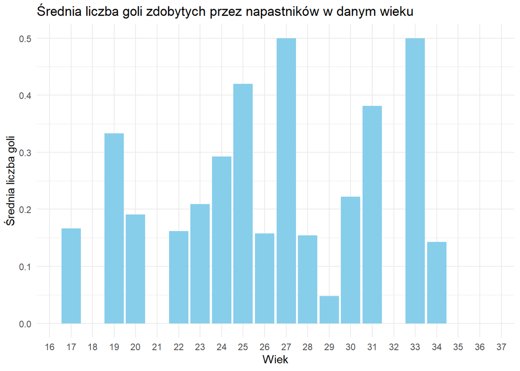

```r
  ggplot(dane, aes(x = as.factor(Age), y = srednia_gole)) +
  geom_bar(stat = "identity", fill = "skyblue") +
  labs(title = "Średnia liczba goli zdobytych przez napastników w danym wieku",
       x = "Wiek",
       y = "Średnia liczba goli") +
  theme_minimal()
```

Zauważam, że napastnicy w wieku 18,21 oraz 32 mają 0 średnią strzelonych bramek. Sprawdzam co jest tego przyczyną.

```r
unique_napastnicy <- data %>%
  filter(Position == "FW" & Age %in% c(18, 21, 32)) %>%
  distinct(Player, .keep_all = TRUE)
print(unique_napastnicy$Player)
```

```
##  [1] "Mehdi Taremi"      "Federico Cassa"    "Tommaso Baldanzi"
##  [4] "Gaetano Oristanio" "Matìas Soulé"      "Ismael Konate"
##  [7] "Ange-Yoan Bonny"   "Mathis Lambourde"  "Álvaro Morata"
## [10] "Giovanni Fabbian"
```

Początkowe podejrzenie, że w lidze tej nie występują napastnicy w wieku 18,21 oraz 32 było błędne, ponieważ jest 10 takich napastników. Po prostu nie strzelili oni żadnych bramek w tym sezonie Serie A.

Ogólne wnioski:

Najwyższą średnią liczbę goli posiadają napastnicy w wieku 25,27 oraz 33 lata. Może to wynikać przede wszystkim z ich dużego doświadczenia oraz w miarę młodego wieku w przypadku zawodników mających 27 lat. Zauważalne jest również, że zawodnicy w wieku od 20 do 23 oraz od 34 i wyżej mają wyraźnie mniejszą przeciętną liczbę strzelonych bramek. W przypadku tych pierwszych wynikać to może z mniejszego doświadczenia oraz mniejszej ilości minut spędzonych na boisku. Natomiast w przypadku zawodników starszych wynikać to może z ich zbyt szybkiego męczenia się i znacznego obniżenia formy.

### 2. Czy czas spędzony na boisku ma wpływ na liczbę strzelonych przez napastnika goli?

W pierwszej kolejności tworzymy zmienną ‘napastnicy’, która zawiera piłkarzy grających na pozycji FW.

```r
napastnicy <- data %>%
  filter(Position == "FW")
```

Rysujemy wykres przedstawiający liczbę goli strzelonych przez napastników w zależności od tego ile minut spędzili oni na boisku.

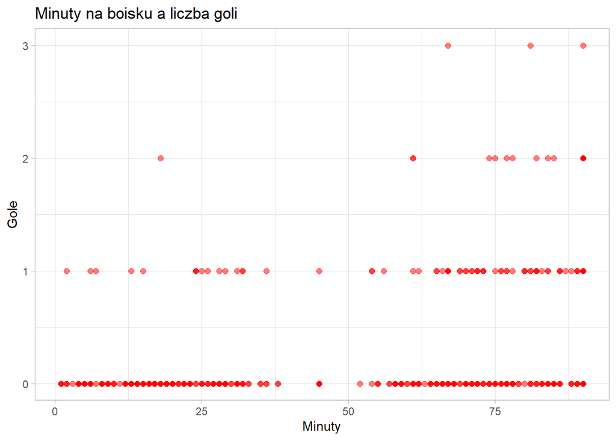

```r
ggplot(napastnicy,aes(x = Minutes, y = Goals)) +
  theme_light() +
  geom_point(alpha = 0.5, size = 2, color = "red") +
  labs(title = "Minuty na boisku a liczba goli", x = "Minuty", y = "Gole")
```

Na podstawie wykresu zauważyć można, że dotychczas w rozgrywkach Serie A jedynie 3 razy napastnikom udało się strzelić hattricka, co więcej każdy z hattricków został strzelony przez zawodnika, który grał powyżej 65 minut w danym meczu. Wynik, któremu warto się przyjrzeć to ten, że któremuś zawodnikowi udało się strzelić 2 bramki będac na boisku jedynie 18 minut.

Ogólne wnioski:

Długość czasu spędzonego na boisku zdecydowanie ma wpływ na ilość strzelonych bramek. O ile niektórzy zawodnicy strzelali po jednej bramce będąc na boisku nawet 2 minuty, o tyle strzelenie dwóch lub większej ilości bramek wymagało od zawodników grania przez co najmniej 18 minut.

### 3. Która drużyna jest najbardziej skuteczna? Czyli ilość strzałów w stosunku do rzeczywiście strzelonych goli.

Najpierw stwórzmy zmienną, która będzie przechowywała informacje o łącznej sumie strzałów, sumie goli oraz procencie strzałów, który został zamieniony na bramkę. Dane te będą pogrupowane według zespołu

```r
statystyki_druzyn <- data %>%
  group_by(Team) %>%
  summarise(
    suma_goli = sum(Goals, na.rm = TRUE),
    suma_strzałów = sum(`Total_Shoot`, na.rm = TRUE),
    procent_strzałów = (suma_goli / suma_strzałów) * 100
  )
```

Teraz przekształcamy format szeroki na format długi.

```r
statystyki_druzyn2 <- statystyki_druzyn %>%
  pivot_longer(cols = c(suma_goli, suma_strzałów), names_to = "Wyniki", values_to = "Wartość")
```

Tworzę wykres słupkowy przedstawiający sumę strzałów i sumę bramek dla każdej drużyny.

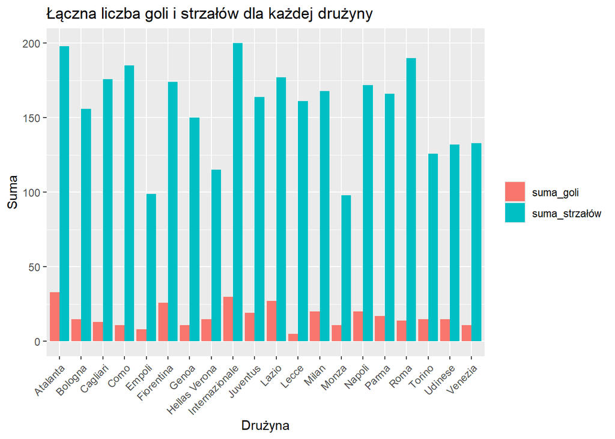

```r
ggplot(statystyki_druzyn2, aes(x = Team, y = Wartość, fill = Wyniki)) +
  geom_bar(stat = "identity", position = "dodge") +
  labs(title = "Łączna liczba goli i strzałów dla każdej drużyny",
       x = "Drużyna", y = "Suma", fill = "") +
  theme(axis.text.x = element_text(angle = 45, hjust = 1))
```

Ogólne wnioski:

Do najbardziej aktywnych ofensywnie drużyn należą Atalanta, Internazionale oraz Roma. Wbrew pozorom duża ilość oddanych strzałów nie zawsze przekłada się na dużą ilość zdobytych bramek. Internazionale mimo tego, że oddało najwięcej strzałów nie ma największej ilości zdobytych bramek. Kolejnym tego przykładem jest drużyna Lecce, która oddała stosunkowo dużą ilość strzałów, bo ponad 160, ma najmniej strzelonych bramek, ze wszystkich drużyn.

Teraz stworzymy wykres pokazujący procentową skuteczność każdej z drużyn.

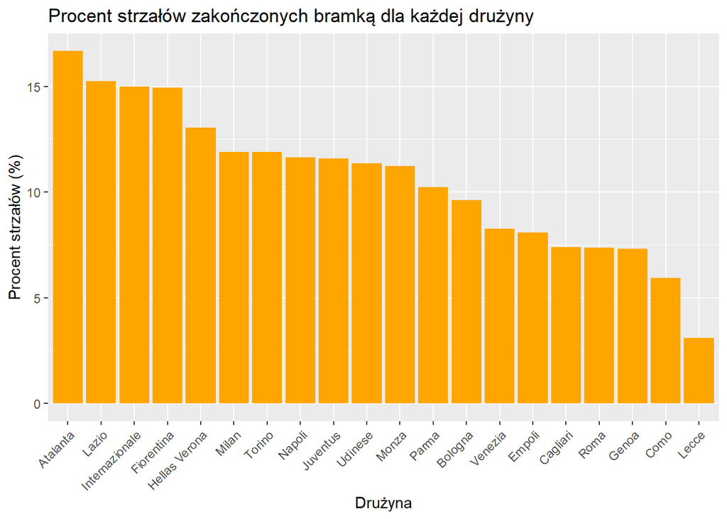

```r
 ggplot(statystyki_druzyn, aes(x = fct_reorder(Team, procent_strzałów, .desc = TRUE),y = procent_strzałów)) +
  geom_bar(stat = "identity", fill = "orange") +
  labs(title = "Procent strzałów zakończonych bramką dla każdej drużyny",
       x = "Drużyna", y = "Procent strzałów (%)") +
  theme(axis.text.x = element_text(angle = 45, hjust = 1))
```

Malejące uporządkowanie drużyn według skuteczności pozwoliło nam zweryfikować wcześniejsze podejrzenia. O ile drużyny takie jak Atalanta i Internazionale wraz z dużą ilością oddanych strzałów posiadają również dużą ilość strzelonych bramek, o tyle Roma, która uchodziła za trzecią najbardziej ofensywną drużynę jest czwarta od końca pod kątem skuteczności. Co ciekawe powyższy ranking skuteczności drużyn częściowo przekłada ostateczne zestawienie punktowe w tym sezonie Serie A. Drużyny takie jak Atalanta, Lazio i Internazionale, które są na podium pod kątem skuteczności zajmują odpowiednio pierwsze, piąte i trzecie miejsce w obecnym sezonie Serie A. Z kolei Lecce, które ma najgorszą skuteczność jest dopiero szesnaste w tabeli.

### 4. Czy pozycja zawodnika ma wpływ na ilość wykonanych przez niego podań?

Ustalamy podstawowe statystyki opisowe dotyczące wykonanych udanych podań w zależności od pozycji zawodnika.

```r
podania <- data %>%
  group_by(Position) %>%
  summarise(
    srednia_podania = mean(`Passes_Completed`, na.rm = TRUE),
    odchylenie_podania = sd(`Passes_Completed`, na.rm = TRUE),
    min_podania = min(`Passes_Completed`, na.rm = TRUE),
    max_podania = max(`Passes_Completed`, na.rm = TRUE),
    Q1_podania = quantile(`Passes_Completed`, 0.25, na.rm = TRUE),
    Q3_podania = quantile(`Passes_Completed`, 0.75, na.rm = TRUE)
  )

podania
```

```
## # A tibble: 13 × 7
##    Position srednia_podania odchylenie_podania min_podania max_podania
##    <chr>              <dbl>              <dbl>       <dbl>       <dbl>
##  1 AM                 15.4               11.4            0          65
##  2 CB                 42.8               23.1            0         132
##  3 CM                 26.5               20.8            0         116
##  4 DM                 31.6               20.2            0          99
##  5 FW                  8.88               6.81           0          48
##  6 GK                 25.5                8.61           8          59
##  7 LB                 32.5               20.1            0          90
##  8 LM                 16.5               12.9            1          51
##  9 LW                 13.3                9.28           0          39
## 10 RB                 32.5               20.8            1         100
## 11 RM                 19.7               19.2            1          80
## 12 RW                 14.6               10.8            0          52
## 13 WB                 22.0               14.3            0          72
## # ℹ 2 more variables: Q1_podania <dbl>, Q3_podania <dbl>
```

### 5. Czy wiek zawodnika ma wpływ na ilość wykonanych przez niego dryblingów?

Najpierw utworzymy zmienną przechowującą przeciętną liczbę dryblingów w zależności od wieku zawodnika.

```r
wiek_dryblingi <- data %>%
  group_by(Age) %>%
  summarise(
    srednia_dryblingi = mean(Dribble_Attempts, na.rm = TRUE) )
```

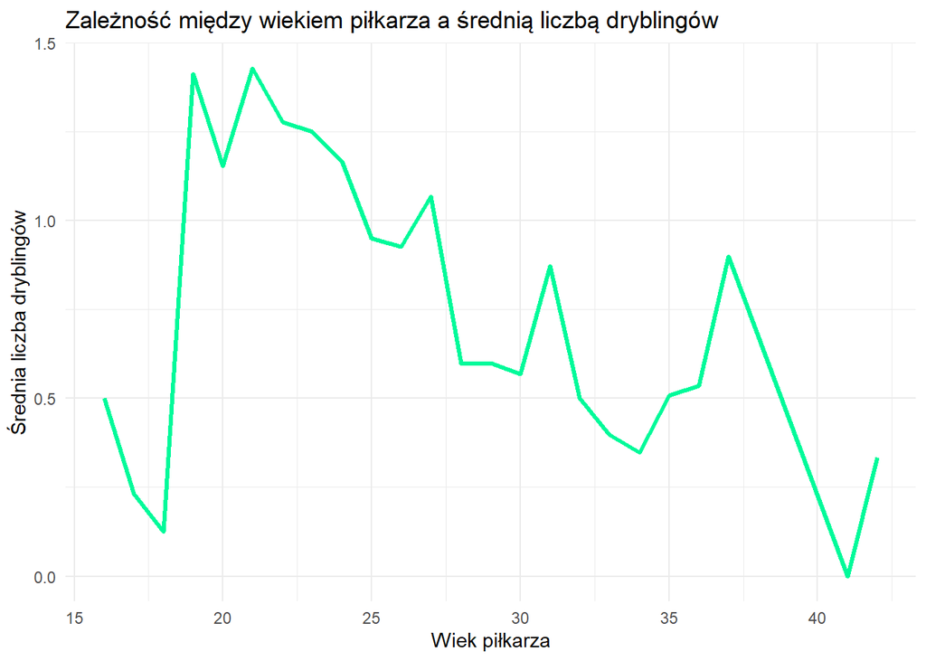

```r
ggplot(wiek_dryblingi, aes(x = Age, y = srednia_dryblingi)) +
  geom_line(color = "mediumspringgreen", size = 1.2) +
  theme_minimal() +
  labs(
    title = "Zależność między wiekiem piłkarza a średnią liczbą dryblingów",
    x = "Wiek piłkarza",
    y = "Średnia liczba dryblingów"
  )
```

### 6. Czy pozycja zawodnika ma wpływ na ilość zdobytych przez niego kartek?

W pierwszej kolejności tworzymy zmienną przechowującą średnią ilość zdobytych żółtych i czerownych kartek grupując to według pozycji, a następnie zamieniamy format szeroki na długi.

```r
dane_kartki <- data %>%
  group_by(Position) %>%
  summarise(
    czerwone_kartki = mean(`Red_Cards`, na.rm = TRUE),
    zolte_kartki = mean(`Yellow_Cards`, na.rm = TRUE)
  ) %>%
  pivot_longer(cols = c(czerwone_kartki, zolte_kartki), names_to = "Rodzaj_kartki", values_to = "Srednia")
```

Teraz tworzymy wykres przedstawiający przeciętną wartość żółtych i czerwonych kartek w zależności od pozycji.

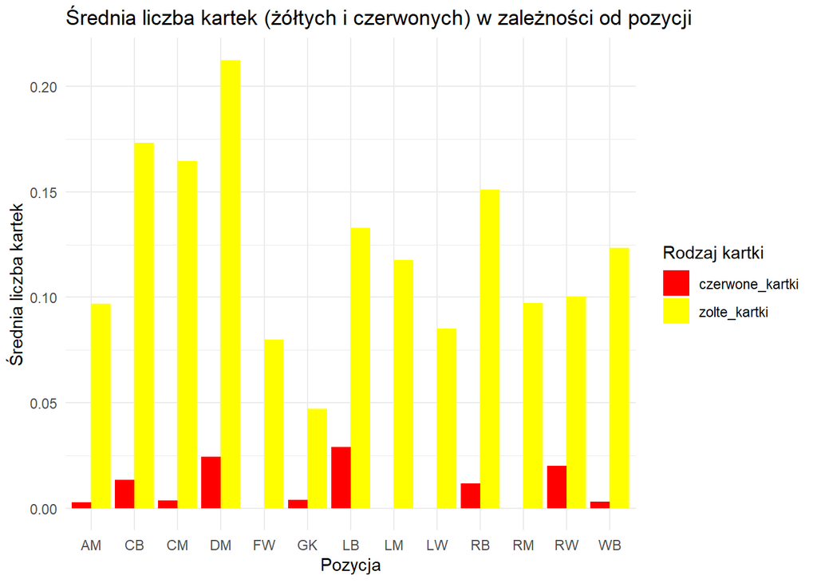

```r
ggplot(dane_kartki, aes(x = Position, y = Srednia, fill = Rodzaj_kartki)) +
  geom_bar(stat = "identity", position = "dodge") +
  labs(
    title = "Średnia liczba kartek (żółtych i czerwonych) w zależności od pozycji",
    x = "Pozycja",
    y = "Średnia liczba kartek",
    fill = "Rodzaj kartki"
  ) +
  scale_fill_manual(values = c("zolte_kartki" = "yellow", "czerwone_kartki" = "red"))+
theme_minimal()
```

### 7. Czy wiek zawodnika ma wpływ na liczbę rozegranych przez niego minut?

W pierwszej kolejności tworzę zmienną przechowującą przeciętną ilość rozegranych przez piłkarza minut w zależności od jego wieku.

```r
dane_srednie_minuty <- data %>%
  group_by(Age) %>%
  summarise(srednia_minut = mean(Minutes, na.rm = TRUE))
```

Rysuję wykres obrazujący tę zależność

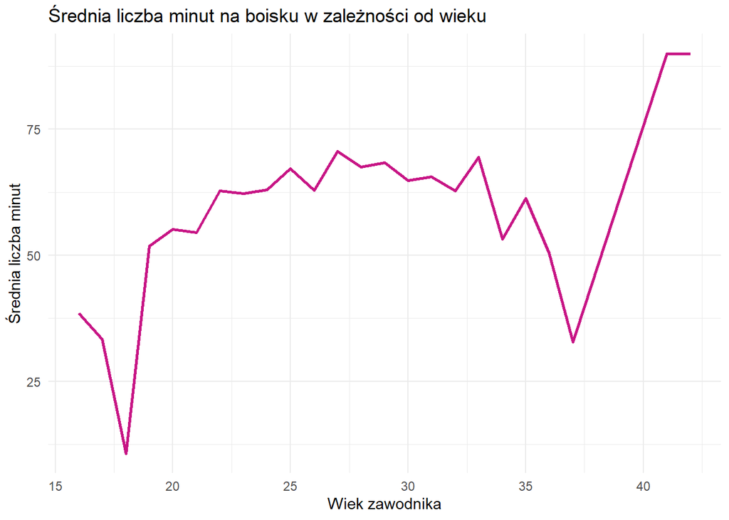

```r
ggplot(dane_srednie_minuty, aes(x = Age, y = srednia_minut)) +
  geom_line(color = "mediumvioletred", size = 1) +
  labs(
    title = "Średnia liczba minut na boisku w zależności od wieku",
    x = "Wiek zawodnika",
    y = "Średnia liczba minut"
  ) +
  theme_minimal()
```

Ogólne wnioski:

Zauważamy, że zawodnicy w wieku 16–18 lat spędzają na boisku mniej minut, z wyraźnym dołkiem w okolicach 18 roku życia. Dopiero w wieku 19 lat zauważalny jest wyraźny wzrost co spowodowane może być nabraniem odpowiedniego doświadczenia i zdobyciem zaufania trenera. Najdłuższa przeciętna ilość czasu spędzonego na boisku widoczna jest wśród zawodników pomiędzy 22 a 33 rokiem życia, co może wynikać z największej wytrzymałości fizycznej tych zawodników. Ciekawy jest znaczny wzrost czasu spędzonego na boisku wśród zawodników w wieku większym niż 36. Wynikać to może przede wszystkim z małej ilości zawodników w tym wieku.

Wypisujemy zawodników w wieku powyżej 36, aby poznać przyczynę nagłego wzrostu na wykresie.

```r
zawodnicy_powyzej_36 <- data %>%
  filter(Age > 36) %>%
  select(Player, Age, Minutes, Team)

zawodnicy_powyzej_36
```

```
## # A tibble: 15 × 4
##    Player             Age Minutes Team
##    <chr>            <int>   <dbl> <chr>
##  1 Francesco Caputo    37       6 Empoli
##  2 Pedro               37       4 Lazio
##  3 Pepe Reina          41      90 Como
##  4 Pepe Reina          41      90 Como
##  5 Pepe Reina          42      90 Como
##  6 Pedro               37      23 Lazio
##  7 Pedro               37      18 Lazio
##  8 Pedro               37      24 Lazio
##  9 Pedro               37      29 Lazio
## 10 Pedro               37      78 Lazio
## 11 Pepe Reina          42      90 Como
## 12 Pedro               37      28 Lazio
## 13 Pepe Reina          42      90 Como
## 14 Pedro               37      59 Lazio
## 15 Pedro               37      59 Lazio
```

Zgodnie z podejrzeniami nagły wzrost spowodowany był małą ilością zawodników w tym zakresie wieku, którzy rozegrali dużą ilość minut.

### 8. Czy Włosi są główną narodowością grającą w Serie A?

W pierwszej kolejności przygotowujemy zestawienie unikalnych piłkarzy i ich narodowości, ponieważ w naszych danych nazwiska wielokrotnie sie pojawiają z powodu występowania w dużej ilości spotkań.

```r
  unikalni_pilkarze <- data %>%
    distinct(Player, Nation)
```

Teraz zebranych wcześniej unikalnych piłkarzy dzielimy ze względu na narodowość, a każdej narodowości przypisujemy liczbę piłkarzy, którzy z niej są.

```r
  liczba_pilkarzy_na_narodowosc <- unikalni_pilkarze %>%
    group_by(Nation) %>%
    summarise(liczba_pilkarzy = n())
```

Mając już gotową listę 74 narodowości oraz ilość piłkarzy w każdej z nich przygotujemy 10 narodowości o największej liczbie piłkarzy w Serie A, co ułatwi analizę i pozwoli ominąć nieznaczące państwa o małej liczbie zawodników.

```r
  top_10_narodowosci <- liczba_pilkarzy_na_narodowosc %>%
    arrange(desc(liczba_pilkarzy)) %>%
    head(10)

top_10_narodowosci
```

```
## # A tibble: 10 × 2
##    Nation liczba_pilkarzy
##    <chr>            <int>
##  1 ITA                167
##  2 FRA                 37
##  3 ARG                 23
##  4 ESP                 17
##  5 BRA                 15
##  6 NED                 12
##  7 BEL                 11
##  8 CRO                 11
##  9 POL                 11
## 10 DEN                 10
```

Teraz piłkarzom, którzy nie należą do 10 największych narodowości przypiszemy narodowość “POZOSTAŁE”, która będzie reprezentować mniejszości.

```r
  liczba_pilkarzy_na_narodowosc <- liczba_pilkarzy_na_narodowosc %>%
    mutate(Nation = ifelse(Nation %in% top_10_narodowosci$Nation, as.character(Nation), "POZOSTAŁE")) %>%
    group_by(Nation) %>%
    summarise(liczba_pilkarzy = sum(liczba_pilkarzy))
```

Dodajemy kolumnę, która będzie przechowywać informacje o procentowym udziale piłkarzy z danej narodowości w ogólnej liczbie piłkarzy występujących w tej lidze.

```r
  suma_pilkarzy <- sum(liczba_pilkarzy_na_narodowosc$liczba_pilkarzy)

  liczba_pilkarzy_na_narodowosc <- liczba_pilkarzy_na_narodowosc %>%
    mutate(procent_udzialu = (liczba_pilkarzy / suma_pilkarzy) * 100)

  liczba_pilkarzy_na_narodowosc
```

```
## # A tibble: 11 × 3
##    Nation    liczba_pilkarzy procent_udzialu
##    <chr>               <int>           <dbl>
##  1 ARG                    23            4.59
##  2 BEL                    11            2.20
##  3 BRA                    15            2.99
##  4 CRO                    11            2.20
##  5 DEN                    10            2.00
##  6 ESP                    17            3.39
##  7 FRA                    37            7.39
##  8 ITA                   167           33.3
##  9 NED                    12            2.40
## 10 POL                    11            2.20
## 11 POZOSTAŁE             187           37.3
```

Teraz rysujemy wykres przedstawiający to zestawienie

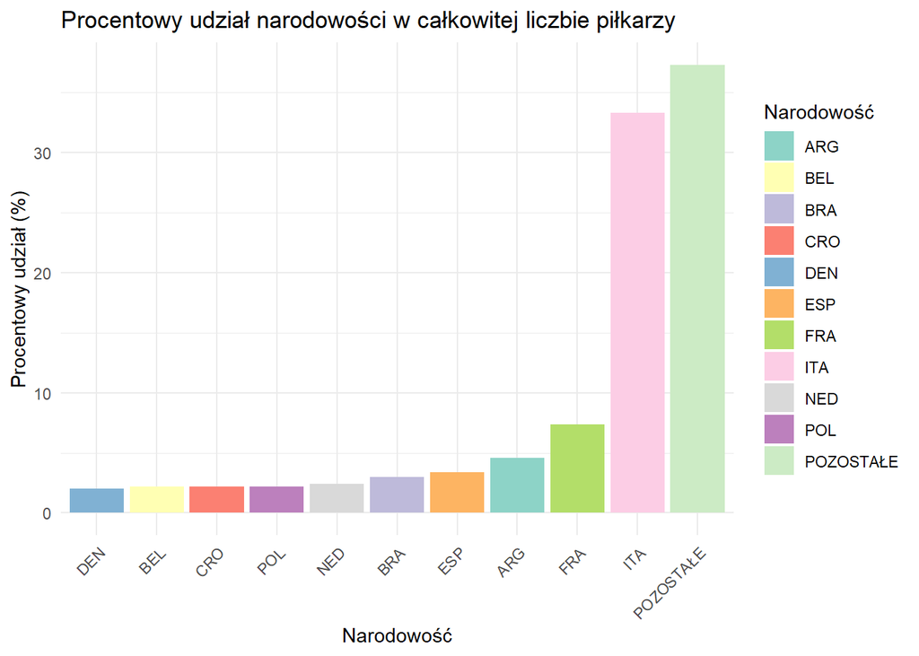

```r
  ggplot(liczba_pilkarzy_na_narodowosc, aes(x = reorder(Nation, procent_udzialu), y = procent_udzialu, fill = Nation)) +
    geom_bar(stat = "identity") +
    scale_fill_brewer(palette = "Set3") +
    labs(title = "Procentowy udział narodowości w całkowitej liczbie piłkarzy",
         x = "Narodowość", y = "Procentowy udział (%)", fill = "Narodowość") +
    theme_minimal() +
    theme(axis.text.x = element_text(angle = 45, hjust = 1))
```

Ogólne wnioski:

Największy udział, bo ponad 35% mają zawodnicy spoza 10 najliczniejszych narodowości, co wskazuje na dużą różnorodność mniej reprezentowanych krajów. Ponadto Włosi pomimo tego, że teoretycznie dominują procentowy udział to posiadają jedynie 33% ze wszystkich zawodników. Ku mojemu zaskoczeniu na liście 10 najbardziej reprezentowanych krajów znalazła się Polska.

Możemy spojrzeć jacy polscy zawodnicy grają na boiskach Serie A:

```r
polscy_pilkarze <- unikalni_pilkarze %>%
  filter(Nation == "POL") %>%
  select(Player,Nation)

print(polscy_pilkarze)
```

```
## # A tibble: 11 × 2
##    Player                Nation
##    <chr>                 <chr>
##  1 Karol Linetty         POL
##  2 Sebastian Walukiewicz POL
##  3 Paweł Dawidowicz      POL
##  4 Łukasz Skorupski      POL
##  5 Mateusz Wieteska      POL
##  6 Nicola Zalewski       POL
##  7 Filip Marchwiński     POL
##  8 Kacper Urbanski       POL
##  9 Mateusz Kowalski      POL
## 10 Piotr Zieliński       POL
## 11 Adrian Benedyczak     POL
```

### 9. Czy pozycja zawodnika ma wpływ na jego liczbę kontaktów z piłką?

Najpierw tworzymy zmienną przechowującą informacje dotyczące sumy kontaktów z piłką pogrupowane według piłkarza i pozycji.

```r
kontakty <- data %>%
  group_by(Player,Position) %>%
  summarise(kontakty_suma = sum(Touches, na.rm = TRUE))
```

Teraz rysujemy wykres pudełkowy z wąsem na podstawie wcześniej zebranych informacji.

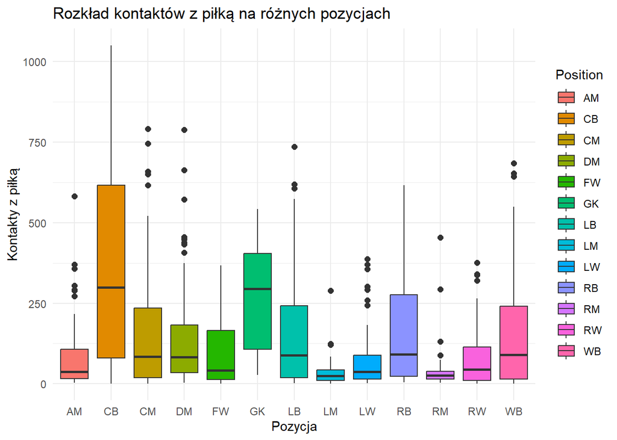

```r
ggplot(kontakty, aes(x = Position, y = kontakty_suma)) +
  geom_boxplot(aes(fill = Position), outlier.size = 2) +
  labs(title = "Rozkład kontaktów z piłką na różnych pozycjach",
       x = "Pozycja",
       y = "Kontakty z piłką")+
  theme_minimal()
```

Ogólne wnioski:

Najwięcej kontaków z piłką mają zawodnicy grający na pozycjach CB i GK. Pozycja CB charakteryzuje się bardzo wysoką medianą oraz szerokim rozkładem wartości. Wynikać to może z tego, że środkowi obrońcy często rozgrywają piłkę od tyłu i pomagają przy konstruowaniu większości akcji. Zauważyć można również, że najmniej kontaków z piłką mają zawodnicy grający na bokach boiskach, czyli LM, RM, LW oraz RW. Wynikać to może z ich roli na boisku, czyli bardzo często szybkie rozgrywanie piłki i bieganie wzdłuż linii bocznych. Ponadto duże skoncentrowanie wartości na pozycjach AM, LM, RM może wskazywać, że wszyscy zawodnicy z Serie A na tych pozycjach grają w bardzo podobny sposób a ich liczba kontaktów z piłką jest bardzo zbliżona, czego nie można powiedzieć o pozycjach CB, LB lub RB.

### 10. Jak rozkładają się rozegrane minuty wśród zawodników zespołu Internazionale?

Pozwoliłem sobie zbadać podstawowe statystyki opisowe zespołu Internazionale dotyczące rozegranych minut przez zawodników tego zespołu, ponieważ jest to mój ulubiony zespół występujący na boiskach Serie A.

Tworzę zmienną, która posiada dane przefiltrowane według zespołu, a następnie pogrupowane według każdego grającego tam zawodnika i z tak wydobytych danych ustalam dla każdego z nich podstawowe statystyki opisowe dotyczące minut.

```r
podsumowanie_internazionale <- data %>%
  filter(Team == "Internazionale") %>%
  group_by(Player) %>%
  summarise(
    srednia_minuty = mean(Minutes, na.rm = TRUE),
    odchylenie_minuty = sd(Minutes, na.rm = TRUE),
    min_minuty = min(Minutes, na.rm = TRUE),
    max_minuty = max(Minutes, na.rm = TRUE),
    Q1_minuty = quantile(Minutes, 0.25, na.rm = TRUE),
    Q3_minuty = quantile(Minutes, 0.75, na.rm = TRUE)
  )

podsumowanie_internazionale
```

```
## # A tibble: 23 × 7
##    Player       srednia_minuty odchylenie_minuty min_minuty max_minuty Q1_minuty
##    <chr>                 <dbl>             <dbl>      <dbl>      <dbl>     <dbl>
##  1 Alessandro …           76.5              11.7         60         90      67.8
##  2 Benjamin Pa…           76.3              23.6         26         90      69
##  3 Carlos Augu…           37.6              31.1          9         90      17.5
##  4 Davide Frat…           48.4              34.5          7         90      23.5
##  5 Denzel Dumf…           48                31.5         19         90      23.5
##  6 Federico Di…           79.6              10.3         64         90      73.2
##  7 Francesco A…           74.4              31.0         14         90      90
##  8 Hakan Çalha…           63.3              28.9         11         90      60
##  9 Henrikh Mkh…           80.2              13.7         55         90      65
## 10 Joaquín Cor…           32.8              38.7          5         90      14
## # ℹ 13 more rows
## # ℹ 1 more variable: Q3_minuty <dbl>
```

Na podstawie tych statystyk można dokonać próby ocenienia, który z zawodników jaką pełni rolę w zespole.

Od razu w oczy rzucają się zawodnicy: Henrikh Mkhitaryan, Lautaro Martínez i Federico Dimarco, którzy nie tylko mają najwyższy przeciętny czas spędzony na boisku, ale również stosunkowo niskie odchylenia standardowe oraz bardzo wysokie czasy minimalne, ponieważ żaden z nich nie spada poniżej 55 minut.

Z tego wnioskowania oczywiście należy wykluczyć piłkarza jakim jest Yann Sommer, ponieważ jako podstawowy bramkarz w każdej ze statystyk będzie miał 90 minut.

Z drugiej strony wyznaczyć można zawodników, którzy nie zbyt dużego udziału w grze klubu. Są to Tajon Buchanan oraz Tiago Palacios. Obaj na boisku pojawili się tylko raz, z czego jeden na 17 minut, a drugi jedynie na 10.